# LoneWolf (U1800) Season 22

Season stats and awards

[figure not shown]

### Overview

- The [season](https://www.lichess4545.com/lonewolf/season/22u1800/summary/) was played from 25 May 2021 to 8 August 2021.
- 125 players took part, playing 465 games in total. The season’s forfeit rate was 11.1 per cent.[^1]
- White won 224 games (48.3%), 35 games (7.5%) were drawn, and Black won 205 games (44.2%).[^2]
- 294 games ended with a resignation, 128 games by checkmate, 7 games by time running out, and 1 games by stalemate.

[figure not shown]

1st place

[mdpotts22](https://www.lichess4545.com/lonewolf/season/22u1800/player/mdpotts22/)

2nd place

[walfie](https://www.lichess4545.com/lonewolf/season/22u1800/player/walfie/)

3rd place

[ztraynor](https://www.lichess4545.com/lonewolf/season/22u1800/player/ztraynor/)

#### Story of the season

[figure not shown]

### Game times / durations

#### When were games played?

[figure not shown]

#### How long did games take?

[figure not shown]

#### Longest games (moves)

*Includes games ranked at or above the 90th percentile by number of moves.*

| Rank | Players / Link | Date | Moves |
| --- | --- | --- | --- |
| 1 | teg - synonymousse | Sun 1 Aug 2021 | 86 |
| 2 | rodekio - Agood2inches | Tue 27 Jul 2021 | 78 |
| 3 | kinozarco - CJHendo | Sat 17 Jul 2021 | 75 |
| 4 | adwaitriemann - DanHMarcos | Sun 18 Jul 2021 | 74 |
| 5 | DanHMarcos - remypond | Sun 11 Jul 2021 | 73 |
| 5 | aura_k484 - aznw | Sun 4 Jul 2021 | 73 |
| 5 | adwaitriemann - estebuey | Sun 4 Jul 2021 | 73 |
| 5 | Nairwolf - Dinasword | Thu 1 Jul 2021 | 73 |
| 5 | stan_programmer - Mbourke28 | Sat 12 Jun 2021 | 73 |
| 6 | SedNomini - laskontti | Sat 26 Jun 2021 | 72 |

[output cut: 34 more lines]

#### Longest games

*Includes games ranked at or above the 90th percentile by total clock time.*[^3]

| Rank | Players / Link | Date | Total time |
| --- | --- | --- | --- |
| 1 | aura_k484 - aznw | Sun 4 Jul 2021 | 2h 0m 16s |
| 2 | thepaul1 - wmakos | Sat 7 Aug 2021 | 1h 57m 45s |
| 3 | msck1 - rodekio | Wed 9 Jun 2021 | 1h 57m 8s |
| 4 | KaiM_03 - Ferchosalgado | Sat 29 May 2021 | 1h 51m 24s |
| 4 | rodekio - Agood2inches | Tue 27 Jul 2021 | 1h 51m 24s |
| 5 | systemsson1927 - mxklawz | Tue 25 May 2021 | 1h 51m 10s |
| 6 | mxklawz - ekopp2000 | Sat 5 Jun 2021 | 1h 50m 59s |
| 7 | ztraynor - walfie | Wed 4 Aug 2021 | 1h 50m 19s |
| 8 | remypond - ekopp2000 | Sat 19 Jun 2021 | 1h 49m 46s |
| 9 | stan_programmer - Mbourke28 | Sat 12 Jun 2021 | 1h 49m 34s |

[output cut: 34 more lines]

### By board / rating band

#### ACPL / blunder rate

[figure not shown]

#### Games with lowest combined ACPL

The games with the lowest combined ACPL (including draws).

| Players / Link | Result | Sum ACPL | Date |
| --- | --- | --- | --- |
| SupraScud - mostruash2 | 0-1 | 32 | Thu 17 Jun 2021 |
| thepaul1 - ztraynor | 1-0 | 33 | Sun 18 Jul 2021 |
| MajorThunder - spor3 | 0-1 | 34 | Sat 10 Jul 2021 |
| PsyMar2 - MrLigman | 0-1 | 38 | Sat 3 Jul 2021 |
| fulmarsky - MrLigman | 0-1 | 39 | Sun 20 Jun 2021 |
| Enderbrine16 - Ross067 | 0-1 | 39 | Sat 24 Jul 2021 |
| thepaul1 - adwaitriemann | 1-0 | 41 | Sun 11 Jul 2021 |
| Impaired - madamcza | 1-0 | 42 | Sun 6 Jun 2021 |
| matt_chess_play - Oops2Queen | 1-0 | 42 | Fri 28 May 2021 |
| vejen - wernervolkmann | 1-0 | 42 | Sat 24 Jul 2021 |

#### Excl. draws

The *decisive* games with the lowest combined ACPL.

| Players / Link | Result | Sum ACPL | Date |
| --- | --- | --- | --- |
| SupraScud - mostruash2 | 0-1 | 32 | Thu 17 Jun 2021 |
| thepaul1 - ztraynor | 1-0 | 33 | Sun 18 Jul 2021 |
| MajorThunder - spor3 | 0-1 | 34 | Sat 10 Jul 2021 |
| PsyMar2 - MrLigman | 0-1 | 38 | Sat 3 Jul 2021 |
| fulmarsky - MrLigman | 0-1 | 39 | Sun 20 Jun 2021 |
| Enderbrine16 - Ross067 | 0-1 | 39 | Sat 24 Jul 2021 |
| thepaul1 - adwaitriemann | 1-0 | 41 | Sun 11 Jul 2021 |
| Impaired - madamcza | 1-0 | 42 | Sun 6 Jun 2021 |
| matt_chess_play - Oops2Queen | 1-0 | 42 | Fri 28 May 2021 |
| vejen - wernervolkmann | 1-0 | 42 | Sat 24 Jul 2021 |

### Openings - tables

#### Popular openings

All openings played in the season, excluding variations.

| Rank | Opening | Games | White % | 1-0 % | Draw % | 0-1 % | Mean Eval | Avg Rating |
| --- | --- | --- | --- | --- | --- | --- | --- | --- |
| 1 | Sicilian Defense | 71 | 51.4084507042254 | 47.887323943662 | 7.04225352112676 | 45.0704225352113 | -0.0744776119402985 | 1577.85915492958 |
| 2 | Caro-Kann Defense | 44 | 51.1363636363636 | 45.4545454545455 | 11.3636363636364 | 43.1818181818182 | 0.4425 | 1602.32954545455 |
| 3 | French Defense | 35 | 44.2857142857143 | 37.1428571428571 | 14.2857142857143 | 48.5714285714286 | -0.0829411764705882 | 1616.88571428571 |
| 4 | English Opening | 30 | 63.3333333333333 | 60 | 6.66666666666667 | 33.3333333333333 | 0.554285714285714 | 1629.01666666667 |
| 5 | Queen's Gambit Declined | 25 | 56 | 56 | 0 | 44 | 2.9004 | 1606.86 |
| 6 | Italian Game | 24 | 54.1666666666667 | 50 | 8.33333333333333 | 41.6666666666667 | -0.00652173913043478 | 1577.14583333333 |
| 7 | Scandinavian Defense | 22 | 40.9090909090909 | 40.9090909090909 | 0 | 59.0909090909091 | 0.535238095238095 | 1595.27272727273 |
| 8 | Queen's Pawn Game | 21 | 61.9047619047619 | 61.9047619047619 | 0 | 38.0952380952381 | 2.2352380952381 | 1573.2619047619 |
| 9 | Indian Defense | 20 | 60 | 55 | 10 | 35 | 2.83526315789474 | 1617.925 |
| 10 | Slav Defense | 14 | 39.2857142857143 | 35.7142857142857 | 7.14285714285714 | 57.1428571428571 | 1.29461538461538 | 1653.64285714286 |

[output cut: 46 more lines]

#### Popular variations

All openings played in the season, including variations.

| Rank | Opening | Games | White % | 1-0 % | Draw % | 0-1 % | Mean Eval | Avg Rating |
| --- | --- | --- | --- | --- | --- | --- | --- | --- |
| 1 | Sicilian Defense: Alapin Variation | 10 | 60 | 60 | 0 | 40 | 1.79555555555556 | 1576.05 |
| 2 | Indian Defense | 9 | 66.6666666666667 | 55.5555555555556 | 22.2222222222222 | 22.2222222222222 | 1.66111111111111 | 1654.05555555556 |
| 2 | Scandinavian Defense: Mieses-Kotroc Variation | 9 | 55.5555555555556 | 55.5555555555556 | 0 | 44.4444444444444 | 1.57444444444444 | 1642.27777777778 |
| 3 | Caro-Kann Defense: Exchange Variation | 8 | 56.25 | 50 | 12.5 | 37.5 | 0.8675 | 1603.75 |
| 4 | English Opening: Agincourt Defense | 6 | 50 | 50 | 0 | 50 | 3.635 | 1637.5 |
| 4 | French Defense: Exchange Variation | 6 | 58.3333333333333 | 50 | 16.6666666666667 | 33.3333333333333 | 1.698 | 1638.16666666667 |
| 4 | Sicilian Defense: Modern Variations | 6 | 33.3333333333333 | 33.3333333333333 | 0 | 66.6666666666667 | -3.478 | 1564.41666666667 |
| 4 | Sicilian Defense: Old Sicilian | 6 | 41.6666666666667 | 33.3333333333333 | 16.6666666666667 | 50 | -2.224 | 1568.08333333333 |
| 5 | Caro-Kann Defense | 5 | 90 | 80 | 20 | 0 | -0.272 | 1670.2 |
| 5 | Caro-Kann Defense: Panov Attack | 5 | 50 | 40 | 20 | 40 | 3.372 | 1591.2 |

[output cut: 268 more lines]

#### Best for White

The best-scoring main openings for White.

*Includes all main openings played in at least 10 games.*

| Rank | Opening | Games | White's score (%) | White wins (%) | Draws (%) | Black wins (%) | Mean eval after 15 moves | Avg rating |
| --- | --- | --- | --- | --- | --- | --- | --- | --- |
| 1 | English Opening | 30 | 63.3333333333333 | 60 | 6.66666666666667 | 33.3333333333333 | 0.554285714285714 | 1629.01666666667 |
| 2 | Queen's Pawn Game | 21 | 61.9047619047619 | 61.9047619047619 | 0 | 38.0952380952381 | 2.2352380952381 | 1573.2619047619 |
| 3 | Indian Defense | 20 | 60 | 55 | 10 | 35 | 2.83526315789474 | 1617.925 |
| 4 | Queen's Gambit Declined | 25 | 56 | 56 | 0 | 44 | 2.9004 | 1606.86 |
| 5 | Italian Game | 24 | 54.1666666666667 | 50 | 8.33333333333333 | 41.6666666666667 | -0.00652173913043478 | 1577.14583333333 |
| 6 | Sicilian Defense | 71 | 51.4084507042254 | 47.887323943662 | 7.04225352112676 | 45.0704225352113 | -0.0744776119402985 | 1577.85915492958 |
| 7 | Caro-Kann Defense | 44 | 51.1363636363636 | 45.4545454545455 | 11.3636363636364 | 43.1818181818182 | 0.4425 | 1602.32954545455 |
| 8 | King's Indian Defense | 11 | 50 | 45.4545454545455 | 9.09090909090909 | 45.4545454545455 | 1.02636363636364 | 1620.45454545455 |
| 9 | French Defense | 35 | 44.2857142857143 | 37.1428571428571 | 14.2857142857143 | 48.5714285714286 | -0.0829411764705882 | 1616.88571428571 |
| 10 | Scandinavian Defense | 22 | 40.9090909090909 | 40.9090909090909 | 0 | 59.0909090909091 | 0.535238095238095 | 1595.27272727273 |

[output cut: 1 more lines]

#### Best for Black

The best-scoring main openings for Black.

*Includes all main openings played in at least 10 games.*

| Rank | Opening | Games | Black's score (%) | Black wins (%) | Draws (%) | White wins (%) | Mean eval after 15 moves | Avg rating |
| --- | --- | --- | --- | --- | --- | --- | --- | --- |
| 1 | Slav Defense | 14 | 60.7142857142857 | 57.1428571428571 | 7.14285714285714 | 35.7142857142857 | 1.29461538461538 | 1653.64285714286 |
| 2 | Scandinavian Defense | 22 | 59.0909090909091 | 59.0909090909091 | 0 | 40.9090909090909 | 0.535238095238095 | 1595.27272727273 |
| 3 | French Defense | 35 | 55.7142857142857 | 48.5714285714286 | 14.2857142857143 | 37.1428571428571 | -0.0829411764705882 | 1616.88571428571 |
| 4 | King's Indian Defense | 11 | 50 | 45.4545454545455 | 9.09090909090909 | 45.4545454545455 | 1.02636363636364 | 1620.45454545455 |
| 5 | Caro-Kann Defense | 44 | 48.8636363636364 | 43.1818181818182 | 11.3636363636364 | 45.4545454545455 | 0.4425 | 1602.32954545455 |
| 6 | Sicilian Defense | 71 | 48.5915492957746 | 45.0704225352113 | 7.04225352112676 | 47.887323943662 | -0.0744776119402985 | 1577.85915492958 |
| 7 | Italian Game | 24 | 45.8333333333333 | 41.6666666666667 | 8.33333333333333 | 50 | -0.00652173913043478 | 1577.14583333333 |
| 8 | Queen's Gambit Declined | 25 | 44 | 44 | 0 | 56 | 2.9004 | 1606.86 |
| 9 | Indian Defense | 20 | 40 | 35 | 10 | 55 | 2.83526315789474 | 1617.925 |
| 10 | Queen's Pawn Game | 21 | 38.0952380952381 | 38.0952380952381 | 0 | 61.9047619047619 | 2.2352380952381 | 1573.2619047619 |

[output cut: 1 more lines]

#### Popular gambits

All gambit openings played in the season.[^4]

| Rank | Name | Games | White score (%) |
| --- | --- | --- | --- |
| 1 | Smith-Morra Gambit | 4 | 75 |
| 2 | Marshall Gambit | 4 | 50 |
| 3 | Greco Gambit | 3 | 66.6666666666667 |
| 3 | Vienna Gambit | 3 | 66.6666666666667 |
| 4 | Stafford Gambit | 3 | 0 |
| 5 | Evans Gambit | 2 | 100 |
| 6 | Urusov Gambit | 2 | 0 |
| 7 | Andreaschek Gambit | 1 | 100 |
| 7 | Benko Gambit | 1 | 100 |
| 7 | Keidansky Gambit | 1 | 100 |

[output cut: 3 more lines]

#### Gambiteers

The players who enjoyed the most success when playing gambits.[^5]

*Shows all players who scored at least 50% playing gambits in the season (min. games: 2).*

| Rank | Player | Games | % Score |
| --- | --- | --- | --- |
| 1 | Enderbrine16 | 3 | 66.6666666666667 |
| 2 | Kolskegg | 2 | 100 |
| 3 | masoscot44 | 2 | 50 |
| 3 | Rasgarad | 2 | 50 |

### Openings - sunburst

Click on the image below to see a sunburst plot of all openings played in the season.

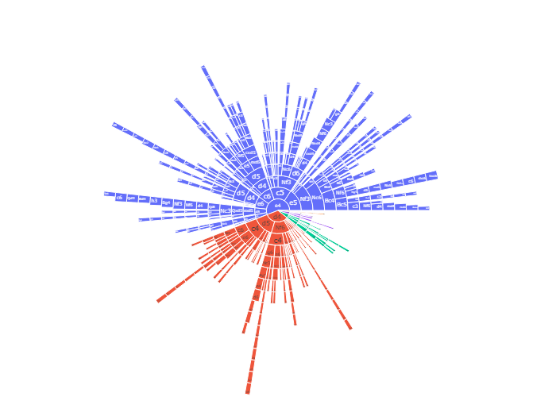

### Awards

Because winning isn’t everything; it’s the only thing :)

See the footnote for further details on selected awards.[^6]

| Award | Description | Winner | Details | Honourable mentions |
| --- | --- | --- | --- | --- |
| x | Archbishop of Accuracy | deanmadden | 33.2 ACPL over 147 moves | willitat, AadityaSharma |
| x | Bullet Boss | Enderbrine16 | 33 moves | estebuey, adwaitriemann |
| x | David Award | Dkeey | Opponents' record: 52.5/73 | lepertoe, ztraynor |
| x | Gambit Guru | Enderbrine16 | 67% from 3 games | Kolskegg, masoscot44 |
| x | Giri Award | furrykef, mdpotts22, msck1, thepaul1, wmakos | 3 draws |  |
| x | Grischuk's Cousin | messyMate | Had 9m 33s left after 10 moves | rdy2burn, walfie |
| x | Houdini Award | ztraynor |  | mdpotts22, joejoepie |
| x | Intimate with Increment | messyMate | 36.5% | ekopp2000, KaiM_03 |
| x | Musing or Snoozing | elusiveky | Spent 34m 25s | flyhalf2k14, flyhalf2k14 |
| x | MVP Award | Impaired | +6-2=2 perf 1810, initially 1320 | greener255, ItalianNoob |

[output cut: 7 more lines]

### Detailed statistics

All the following tables are sortable and searchable.

#### Best performances / highest accuracy

##### Best relative perfs

Shows players’ *relative* performance ratings: season performance rating minus initial rating.[^7]

*Includes all players with a positive relative performance rating over at least five games.*

| # | Player | Games | W | D | L | Initial | Perf | Diff. |
| --- | --- | --- | --- | --- | --- | --- | --- | --- |
| 1 | Impaired | 10 | 6 | 2 | 2 | 1320 | 1810.4 | 490.4 |
| 2 | greener255 | 10 | 5 | 0 | 5 | 1327 | 1717.8 | 390.8 |
| 3 | ItalianNoob | 7 | 4 | 1 | 2 | 1474 | 1815.42857142857 | 341.428571428571 |
| 4 | joejoepie | 11 | 7 | 2 | 2 | 1464 | 1799.63636363636 | 335.636363636364 |
| 5 | wernervolkmann | 5 | 1 | 2 | 2 | 1265 | 1599.8 | 334.8 |
| 6 | AadityaSharma | 6 | 5 | 0 | 1 | 1641 | 1974.16666666667 | 333.166666666667 |
| 7 | aznw | 6 | 4 | 0 | 2 | 1453 | 1769.5 | 316.5 |
| 8 | vejen | 11 | 8 | 0 | 3 | 1561 | 1853.36363636364 | 292.363636363636 |
| 9 | mdpotts22 | 11 | 8 | 3 | 0 | 1745 | 2000.36363636364 | 255.363636363636 |
| 10 | MrJMFun | 11 | 4 | 0 | 7 | 1256 | 1504.18181818182 | 248.181818181818 |

[output cut: 40 more lines]

##### Lowest ACPL

*Includes the 100 players with the lowest ACPL (min. 100 moves played).*

| Rank | Player | Moves | ACPL |
| --- | --- | --- | --- |
| 1 | deanmadden | 147 | 33.2312925170068 |
| 2 | willitat | 303 | 35.3102310231023 |
| 3 | AadityaSharma | 237 | 36.5907172995781 |
| 4 | msck1 | 454 | 38.5198237885463 |
| 5 | thepaul1 | 375 | 38.5306666666667 |
| 6 | Impaired | 472 | 39.2860169491525 |
| 7 | walfie | 386 | 39.419689119171 |
| 8 | fulmarsky | 194 | 39.7886597938144 |
| 9 | mdpotts22 | 425 | 40.7129411764706 |
| 10 | Howah250 | 152 | 41.625 |

[output cut: 90 more lines]

#### Time spent / strongest opponents

##### Time spent

*Includes the 50 players who spent the most clock time over the season.*

| Rank | Player | Games | Total time spent |
| --- | --- | --- | --- |
| 1 | ztraynor | 11 | 8h 11m 23s |
| 2 | mxklawz | 10 | 8h 7m 11s |
| 3 | rdy2burn | 11 | 8h 4m 22s |
| 4 | restausverkauf | 11 | 8h 2m 19s |
| 5 | KaiM_03 | 10 | 8h 0m 0s |
| 6 | rodekio | 11 | 7h 56m 0s |
| 7 | Impaired | 10 | 7h 39m 42s |
| 8 | pinallwizard | 11 | 7h 32m 17s |
| 9 | rickdeckard79 | 11 | 7h 28m 51s |
| 10 | ekopp2000 | 9 | 7h 9m 32s |

[output cut: 40 more lines]

##### Time spent per move (after move 10)

*Includes everyone who played at least three games.*

| Rank | Player | Games | Moves | Time spent per move | Percentile |
| --- | --- | --- | --- | --- | --- |
| 1 | jameslatham | 4 | 61 | 1m 27.0s | 100 |
| 2 | skovsky | 9 | 185 | 1m 26.9s | 99 |
| 3 | Archilas | 7 | 141 | 1m 22.3s | 98 |
| 4 | Kolskegg | 8 | 143 | 1m 22.0s | 97 |
| 5 | El_Pollo_Diablo | 5 | 102 | 1m 19.0s | 96 |
| 6 | danimal_t | 10 | 242 | 1m 18.8s | 95 |
| 7 | BreezyCamel | 3 | 62 | 1m 18.6s | 94 |
| 8 | systemsson1927 | 8 | 193 | 1m 18.1s | 93 |
| 9 | furrykef | 11 | 263 | 1m 17.3s | 92 |
| 10 | pinallwizard | 11 | 314 | 1m 15.7s | 91 |

[output cut: 107 more lines]

##### Strength of schedule

These players faced the most in-form opponents across the season, when judged by their opponents’ collective score in all their other games.[^8]

*Includes all players who faced a collective group of opponents that played at least 15 (other) games across the season with a collective score above 50 per cent.*

| # | Player | Opp Games | Opp Pts | Opp % |
| --- | --- | --- | --- | --- |
| 1 | Dkeey | 73 | 52.5 | 71.9178082191781 |
| 2 | lepertoe | 52 | 37 | 71.1538461538462 |
| 3 | ztraynor | 86 | 60 | 69.7674418604651 |
| 4 | walfie | 88 | 60.5 | 68.75 |
| 5 | wmakos | 88 | 60 | 68.1818181818182 |
| 6 | Nairwolf | 64 | 43.5 | 67.96875 |
| 7 | mdpotts22 | 92 | 61 | 66.304347826087 |
| 8 | Rs4Limo | 34 | 22.5 | 66.1764705882353 |
| 9 | msck1 | 102 | 67 | 65.6862745098039 |
| 10 | ItalianNoob | 48 | 31.5 | 65.625 |

[output cut: 52 more lines]

#### Comebacks and upsets

##### Comebacks

*Includes players with a positive average “comeback margin” that played at least three games.*[^9]

| Rank | Player | Average Comeback Margin | Total Comeback Margin |
| --- | --- | --- | --- |
| 1 | ztraynor | 1.1251558744448 | 12.3767146188928 |
| 2 | mdpotts22 | 1.1080057595264 | 12.1880633547904 |
| 3 | joejoepie | 0.933183821525506 | 10.2650220367806 |
| 4 | walfie | 1.0196349124775 | 10.196349124775 |
| 5 | rdy2burn | 0.897215533235758 | 9.86937086559334 |
| 6 | vejen | 0.895877438674969 | 9.85465182542466 |
| 7 | Agood2inches | 1.21709355708248 | 9.73674845665981 |
| 8 | Dkeey | 1.07495433376903 | 9.6745890039213 |
| 9 | hlex95 | 0.864858600603224 | 9.51344460663546 |
| 10 | wmakos | 0.926980280558094 | 9.26980280558094 |

[output cut: 105 more lines]

##### Biggest upsets

*Includes all players who defeated an opponent rated at least 50 points higher.*

| Rank | Player | Upset Margin |
| --- | --- | --- |
| 1 | Scott9315 | 351 |
| 2 | greener255 | 346 |
| 3 | greener255 | 333 |
| 4 | tpk1024 | 305 |
| 5 | MrJMFun | 294 |
| 6 | greener255 | 292 |
| 7 | wernervolkmann | 286 |
| 7 | Howah250 | 286 |
| 8 | Scott9315 | 284 |
| 9 | kjbetz | 258 |

[output cut: 133 more lines]

##### Repeated upsets

Includes players who achieved multiple wins over opponents rated at least 50 points higher.

| Rank | Player | Total Upset Margin | Upsets | Avg Upset Margin | Biggest Margin |
| --- | --- | --- | --- | --- | --- |
| 1 | greener255 | 1431 | 5 | 286.2 | 346 |
| 2 | Impaired | 1303 | 6 | 217.166666666667 | 251 |
| 3 | MrJMFun | 1048 | 4 | 262 | 294 |
| 4 | ItalianNoob | 722 | 4 | 180.5 | 241 |
| 5 | AleksandrSudak | 702 | 5 | 140.4 | 187 |
| 6 | Scott9315 | 635 | 2 | 317.5 | 351 |
| 7 | Ross067 | 628 | 5 | 125.6 | 154 |
| 8 | dama_x_rey | 606 | 3 | 202 | 231 |
| 9 | tenken | 576 | 3 | 192 | 212 |
| 10 | aznw | 536 | 4 | 134 | 179 |

[output cut: 29 more lines]

#### Dawdlers and instant movers

##### Least time left after move 10

The players with the least time left after 10 moves…who still managed to win![^10]

| Rank | Player | Time left after 10 moves | Link |
| --- | --- | --- | --- |
| 1 | messyMate | 9m 33s | https://lichess.org/m5p6VpY0#20 |
| 2 | rdy2burn | 14m 30s | https://lichess.org/FrbbJFEH#20 |
| 3 | walfie | 14m 45s | https://lichess.org/9zF1M47S#20 |
| 4 | aznw | 16m 17s | https://lichess.org/InXDoz7t#19 |
| 5 | ipr | 17m 30s | https://lichess.org/lwM5bw3y#20 |
| 6 | fulmarsky | 17m 42s | https://lichess.org/GEPeaZgl#20 |
| 7 | ztraynor | 17m 50s | https://lichess.org/2g2e45da#20 |
| 8 | Archilas | 18m 5s | https://lichess.org/BaeUukyr#19 |
| 9 | ztraynor | 18m 10s | https://lichess.org/b9VqKhv0#19 |
| 10 | ekopp2000 | 18m 11s | https://lichess.org/aaSZdlWG#20 |

##### Instant moves

Players who made the most ‘instant’ moves over the season, taking less than 0.5 seconds (includes premoves).

*Includes players with more than five ‘instant’ moves.*

| Rank | Player | Instant moves |
| --- | --- | --- |
| 1 | Enderbrine16 | 33 |
| 1 | estebuey | 33 |
| 2 | adwaitriemann | 27 |
| 3 | CJHendo | 26 |
| 4 | Romain4444 | 20 |
| 5 | furrykef | 15 |
| 6 | Cornelius25 | 14 |
| 7 | spor3 | 13 |
| 8 | egoncharik | 12 |
| 9 | ssyx | 11 |

[output cut: 16 more lines]

#### Longest thinks, time trouble addicts, and lucky escapes

##### Longest thinks

The longest times spent on a single move.

*Top 100 shown.*

| # | Player | Time spent | Colour | Move | Link |
| --- | --- | --- | --- | --- | --- |
| 1 | elusiveky | 34m 25s | White | 19 | https://lichess.org/BdcHQ5n3#37 |
| 2 | flyhalf2k14 | 16m 58s | White | 12 | https://lichess.org/B8EYR15w#23 |
| 3 | flyhalf2k14 | 13m 23s | Black | 15 | https://lichess.org/yijx5avx#30 |
| 4 | walfie | 12m 42s | White | 18 | https://lichess.org/u0n5xVPQ#35 |
| 5 | elusiveky | 12m 23s | White | 20 | https://lichess.org/uFHWf9eH#39 |
| 6 | AadityaSharma | 11m 35s | Black | 10 | https://lichess.org/Mbv4EOt5#20 |
| 7 | mxklawz | 11m 27s | Black | 10 | https://lichess.org/7BMpAv3d#20 |
| 8 | ekopp2000 | 11m 11s | White | 12 | https://lichess.org/bIsuRBQi#23 |
| 9 | wilmsss | 11m 7s | White | 14 | https://lichess.org/f1T1DgCd#27 |
| 10 | ztraynor | 10m 50s | Black | 13 | https://lichess.org/p0purstj#26 |

[output cut: 90 more lines]

##### Time trouble addicts

Shows players by proportion of moves made in time trouble (defined as having less than a minute remaining on the clock).

*Includes everyone who played at least 100 moves over the season while making at least one move in time trouble.*

| # | Player | All moves | With < 1min left | Time Trouble % |
| --- | --- | --- | --- | --- |
| 1 | messyMate | 277 | 101 | 0.364620938628159 |
| 2 | ekopp2000 | 395 | 98 | 0.248101265822785 |
| 3 | KaiM_03 | 426 | 90 | 0.211267605633803 |
| 4 | aura_k484 | 171 | 36 | 0.210526315789474 |
| 5 | mxklawz | 527 | 95 | 0.180265654648956 |
| 6 | synonymousse | 327 | 50 | 0.152905198776758 |
| 7 | furrykef | 369 | 56 | 0.151761517615176 |
| 8 | ztraynor | 487 | 60 | 0.123203285420945 |
| 9 | walfie | 382 | 45 | 0.117801047120419 |
| 10 | lepertoe | 337 | 37 | 0.109792284866469 |

[output cut: 32 more lines]

##### Saved by the bell

Players who made moves with under 5 seconds left on their clock…and still won![^11]

| Player | Moves with under 5s left | Least time left | Link |
| --- | --- | --- | --- |
| walfie | 4 | 2 | https://lichess.org/Z8FIXM7V |
| mxklawz | 3 | 0 | https://lichess.org/zLXMnc45 |
| aura_k484 | 3 | 2 | https://lichess.org/QP9lxlnh |
| ztraynor | 2 | 3 | https://lichess.org/2g2e45da |
| adwaitriemann | 2 | 3 | https://lichess.org/yloQgDDG |

#### Misc. facts

##### Lesser spotted mates

A pawn gave checkmate in 2 games: https://lichess.org/ZaJMvy40, https://lichess.org/1PEGUTzP.

A knight gave checkmate in 8 games: https://lichess.org/8kQbVbMN, https://lichess.org/SaHJE6JI, https://lichess.org/5LWGbRzk, https://lichess.org/KIafbDnu, https://lichess.org/UrauHxU6, https://lichess.org/iFkU2f0i, https://lichess.org/9Ww9vimt, https://lichess.org/W8ixG5nO.

##### Promotions

72 games had at least one promotion. 2 of these saw an under-promotion.

The most promotions seen in a game was 4: https://lichess.org/J6usXzrU

##### Checks and captures

- Most consecutive checks: 19 (https://lichess.org/WobVkXdx)
- Most consecutive captures: 10 (https://lichess.org/2g2e45da)
- Latest-occurring first capture: ply 37 in https://lichess.org/Pny3AxtN

### About this report

- This report was compiled on 23 September 2021.
- These statistics are presented for general interest only. They are not guaranteed to be comprehensive, complete[^12], accurate, or up to date. They may be periodically revised to incorporate updates and bugfixes.
- Any player determined by Lichess to have violated their Terms of Service when this report was compiled should not appear in the detailed statistics.[^13]
- [Homepage](https://rahulan-c.github.io/lichess4545-stats/) / [source code](https://github.com/rahulan-c/lichess4545-stats)
- Acknowledgements: [Noun Project](https://thenounproject.com/) for the award icons; [Simon Ilincev](https://simonilincev.com/) for chess_graph, which produces the openings sunburst plots.
[^1]: The forfeit rate is the percentage of pairings that didn’t result in a game being played.
[^2]: The number of games played in this statistic can differ from the number of games played in the season, as it excludes games where the result of the pairing was later changed to a forfeit win or loss.
[^3]: A game’s total clock time is the sum of both players’ move times from move 2 onwards.
[^4]: Currently, gambit openings are identified by the presence of the term *gambit* in the opening name assigned by Lichess. This is admittedly an imperfect approach as it excludes certain openings that should also be considered as gambits such as the Marshall Attack.
[^5]: Qualifying “gambiteers” are ordered by number of gambit games played before percentage score.
[^6]: *Archbishop of Accuracy*: lowest average centipawn loss (ACPL) over all moves played, as determined by Lichess’s server analysis. Minimum 100 moves played. *David Award*: the player whose opponents achieved the highest percentage score across the season, excluding games against the player. One’s opponents must have played over 20 games (against others) to qualify. Suggested by Tranzoo. *Egalitarian Award*: intended for the team whose players performed most similarly to each other. First, I compute all players’ *relative* performance ratings – the difference between their actual performance rating (using FIDE’s method) and their initial rating. Then I group all players by team, and give the award to the team with the lowest standard deviation across its players’ relative ratings. Suggested by Silkthewanderer. *Gambit Guru*: most gambits played while scoring above 50%. *MVP Award*: minimum 5 games played. *Rookie Award*: minimum 4 games played. *Saved by the Bell*: Excludes moves made in positions with an evaluation of under +300 centipawns from the mover’s perspective. Ordering is determined first by # moves played with under 5 seconds remaining, then by least time remaining in such conditions, then by worst eval faced. *Slingshot Specialist*: the player with the highest total rating gap between their opponents and themselves when only considering wins against opponents rated at least 50 rating points higher.︎
[^7]: The season performance ratings presented in this report may differ slightly from the figures given by the Lichess4545 website. Both figures are based on FIDE’s preferred calculation method and exclude unplayed games (such as forfeit wins/losses and scheduling draws.
[^8]: Both the statistic and the name of its associated award – the David Award – were suggested by **Tranzoo**.
[^9]: Originally suggested by **Lou-E**. This table shows players ranked by the size and number of comebacks achieved over the course of the season. For this purpose, the size of a comeback has been defined as the difference between a player’s final score in a game (0, 0.5, or 1) and the worst evaluation during the game that they faced (which is then converted into a rough win probability for their opponent). For example, if I were to win a game after Lichess’s server analysis gave my opponent a 75% chance of winning in a certain position, then I would have earned 1.75 comeback “points” from the game. My opponent of course would have earned zero points. If the game had been drawn, I would have instead earned only 0.75 comeback “points”.
[^10]: Statistic suggested by **Silkthewanderer**.
[^11]: Excludes moves made in technically winning positions, defined as $\tt eval \le 300$ (from the mover’s perspective). Players are first ordered by number of moves made with 5 seconds or fewer remaining, then by least time remaining in such conditions, and finally by worst eval faced.
[^12]: For example, this report excludes from its analysis all games of less than 5 plies (half-moves), games that ended in a disconnection or by “cheat detected”, games that were aborted, and games that started from a custom position.
[^13]: However, players who were banned from the Lichess4545 leagues after finishing a season in the top three places are still shown with a podium place in that season’s report.